# Jeff’s Variable Analysis

# Executive Summary

This is an analysis of the following predictor variables:  
$ Filler.Level : num 121 119 120 118 119 …  
$ Filler.Speed : int 4002 3986 4020 4012 4010 4014 0 1004 4014 4028 …  
$ Temperature : num 66 67.6 67 65.6 65.6 66.2 65.8 65.2 65.4 66.6 …  
$ Usage.cont : num 16.2 19.9 17.8 17.4 17.7 …  
$ Carb.Flow : int 2932 3144 2914 3062 3054 2948 30 684 2902 3038 …  
$ Density : num 0.88 0.92 1.58 1.54 1.54 1.52 0.84 0.84 0.9 0.9 …  
$ MFR : num 725 727 735 731 723 …  
$ Balling : num 1.4 1.5 3.14 3.04 3.04 …

The following activities were performed:  
1) Review basic statistics for each variable.  
2) Remove rows where response variable value is zero.  
3) Determined high number of zeros for predictor variables were actually missing data so replaced zeros with NAs.  
4) Generated imputed values for all missing data in predictor variables.  
5) Generated boxplots, histograms, and scatter plots for each predictor variable to analyze distributions.  
6) Performed Box Cox transformations for variable with poor distributions.  
7) Performed 1-on-1 regression analysis for each predictor variable against the response variable for numerous regression model focusing on RMSE optimization and compared models results.  
8) Performed a step-wise, both forward and backward, generalize linear model analysis focused on optimizing AIC to identify the most revelant variable relationships.

Variable Analysis Results:  
The predictor variable distributions are generally poor, and all but one variable required a Box Cox-selected transformation which, in most cases, yielded only slight improvements.

The 1-on-1 regression modeling yielding generally poor results with poor RMSE values and terrible R-squared values resulting in the conlusion that no single predictor variable from the set has a significant influence or effect on the response variable.

The step-wise regression modeling resulting in generally poor results as well, but the resulting model did eliminate the variable Filler.Speed when arriving an the final model.

Conclusions:  
None of the predictor variables in this set have a significant influence on PH, and all have troubled data distributions. A comparision of the distribution anomallies should be made across all of the data set variables to determine if there is a systemic cause. Pending that analysis, the variables in this set, minus the Filler.Speed variable, should be combined with other candidate predictor variables for further modeling analysis.

```r
ph.data <- read.csv("/Users/JeffAtLaptop/Dropbox/School/DATA624-PredictiveAnalytics/Project2/StudentData.csv",header = TRUE, stringsAsFactors = FALSE)
summary(ph.data)
```

```
  Brand.Code         Carb.Volume     Fill.Ounces      PC.Volume      Carb.Pressure
 Length:2571        Min.   :0.000   Min.   : 0.00   Min.   :0.0000   Min.   : 0.00
 Class :character   1st Qu.:5.293   1st Qu.:23.92   1st Qu.:0.2370   1st Qu.:65.60
 Mode  :character   Median :5.347   Median :23.97   Median :0.2700   Median :68.00
                    Mean   :5.349   Mean   :23.62   Mean   :0.2729   Mean   :67.47
                    3rd Qu.:5.453   3rd Qu.:24.03   3rd Qu.:0.3110   3rd Qu.:70.60
                    Max.   :5.700   Max.   :24.32   Max.   :0.4780   Max.   :79.40
   Carb.Temp          PSC             PSC.Fill         PSC.CO2           Mnf.Flow
 Min.   :  0.0   Min.   :0.00000   Min.   :0.0000   Min.   :0.00000   Min.   :-100.20
 1st Qu.:138.4   1st Qu.:0.04800   1st Qu.:0.1000   1st Qu.:0.02000   1st Qu.:-100.00
 Median :140.8   Median :0.07600   Median :0.1800   Median :0.04000   Median :  64.80
 Mean   :139.7   Mean   :0.08349   Mean   :0.1936   Mean   :0.05556   Mean   :  24.55
 3rd Qu.:143.8   3rd Qu.:0.11200   3rd Qu.:0.2600   3rd Qu.:0.08000   3rd Qu.: 140.80
 Max.   :154.0   Max.   :0.27000   Max.   :0.6200   Max.   :0.24000   Max.   : 229.40
 Carb.Pressure1  Fill.Pressure   Hyd.Pressure1   Hyd.Pressure2   Hyd.Pressure3
 Min.   :  0.0   Min.   : 0.00   Min.   :-0.80   Min.   : 0.00   Min.   :-1.20
 1st Qu.:118.8   1st Qu.:46.00   1st Qu.: 0.00   1st Qu.: 0.00   1st Qu.: 0.00
 Median :123.0   Median :46.40   Median :11.40   Median :28.60   Median :27.40
 Mean   :121.1   Mean   :47.51   Mean   :12.38   Mean   :20.84   Mean   :20.34
 3rd Qu.:125.4   3rd Qu.:50.00   3rd Qu.:20.20   3rd Qu.:34.60   3rd Qu.:33.20
 Max.   :140.2   Max.   :60.40   Max.   :58.00   Max.   :59.40   Max.   :50.00
 Hyd.Pressure4     Filler.Level    Filler.Speed   Temperature      Usage.cont
 Min.   :  0.00   Min.   :  0.0   Min.   :   0   Min.   : 0.00   Min.   : 0.00
 1st Qu.: 86.00   1st Qu.: 96.2   1st Qu.:3815   1st Qu.:65.20   1st Qu.:18.35
 Median : 96.00   Median :118.2   Median :3980   Median :65.60   Median :21.78
 Mean   : 95.17   Mean   :108.4   Mean   :3605   Mean   :65.61   Mean   :20.95
 3rd Qu.:102.00   3rd Qu.:120.0   3rd Qu.:3996   3rd Qu.:66.40   3rd Qu.:23.74
 Max.   :142.00   Max.   :161.2   Max.   :4030   Max.   :76.20   Max.   :25.90
   Carb.Flow       Density           MFR           Balling       Pressure.Vacuum
 Min.   :   0   Min.   :0.000   Min.   :  0.0   Min.   :-0.170   Min.   :-6.600
 1st Qu.:1133   1st Qu.:0.900   1st Qu.:694.9   1st Qu.: 1.496   1st Qu.:-5.600
 Median :3028   Median :0.980   Median :721.4   Median : 1.648   Median :-5.400
 Mean   :2466   Mean   :1.173   Mean   :646.0   Mean   : 2.197   Mean   :-5.216
 3rd Qu.:3186   3rd Qu.:1.620   3rd Qu.:730.4   3rd Qu.: 3.292   3rd Qu.:-5.000
 Max.   :5104   Max.   :1.920   Max.   :868.6   Max.   : 4.012   Max.   :-3.600
       PH        Oxygen.Filler     Bowl.Setpoint   Pressure.Setpoint Air.Pressurer
 Min.   :0.000   Min.   :0.00000   Min.   :  0.0   Min.   : 0.00     Min.   :140.8
 1st Qu.:8.440   1st Qu.:0.02200   1st Qu.:100.0   1st Qu.:46.00     1st Qu.:142.2
 Median :8.540   Median :0.03340   Median :120.0   Median :46.00     Median :142.6
 Mean   :8.532   Mean   :0.04662   Mean   :109.2   Mean   :47.39     Mean   :142.8
 3rd Qu.:8.680   3rd Qu.:0.05960   3rd Qu.:120.0   3rd Qu.:50.00     3rd Qu.:143.0
 Max.   :9.360   Max.   :0.40000   Max.   :140.0   Max.   :52.00     Max.   :148.2
    Alch.Rel        Carb.Rel      Balling.Lvl
 Min.   :0.000   Min.   :0.000   Min.   :0.000
 1st Qu.:6.540   1st Qu.:5.340   1st Qu.:1.380
 Median :6.560   Median :5.400   Median :1.480
 Mean   :6.873   Mean   :5.416   Mean   :2.049
 3rd Qu.:7.220   3rd Qu.:5.540   3rd Qu.:3.140
 Max.   :8.620   Max.   :6.060   Max.   :3.660
```

```r
suppressWarnings(suppressMessages(library(knitr)))
suppressWarnings(suppressMessages(library(mice)))
suppressWarnings(suppressMessages(library(fBasics)))
# setup the dataset with just jeffs variables
jeffsList <- c("PH","Filler.Level", "Filler.Speed","Temperature","Usage.cont","Carb.Flow","Density","MFR","Balling")
jeffsVars <- data.frame(ph.data[,jeffsList])
summary(jeffsVars)
```

```
       PH         Filler.Level    Filler.Speed   Temperature      Usage.cont
 Min.   :0.000   Min.   :  0.0   Min.   :   0   Min.   : 0.00   Min.   : 0.00
 1st Qu.:8.440   1st Qu.: 96.2   1st Qu.:3815   1st Qu.:65.20   1st Qu.:18.35
 Median :8.540   Median :118.2   Median :3980   Median :65.60   Median :21.78
 Mean   :8.532   Mean   :108.4   Mean   :3605   Mean   :65.61   Mean   :20.95
 3rd Qu.:8.680   3rd Qu.:120.0   3rd Qu.:3996   3rd Qu.:66.40   3rd Qu.:23.74
 Max.   :9.360   Max.   :161.2   Max.   :4030   Max.   :76.20   Max.   :25.90
   Carb.Flow       Density           MFR           Balling
 Min.   :   0   Min.   :0.000   Min.   :  0.0   Min.   :-0.170
 1st Qu.:1133   1st Qu.:0.900   1st Qu.:694.9   1st Qu.: 1.496
 Median :3028   Median :0.980   Median :721.4   Median : 1.648
 Mean   :2466   Mean   :1.173   Mean   :646.0   Mean   : 2.197
 3rd Qu.:3186   3rd Qu.:1.620   3rd Qu.:730.4   3rd Qu.: 3.292
 Max.   :5104   Max.   :1.920   Max.   :868.6   Max.   : 4.012
```

```r
# run the basic stats on the variables
# Let's start by exploring the type of each variable
types <- sapply(1:length(jeffsVars),function(x) typeof(jeffsVars[,x]))
types.df <- data.frame(VAR=names(jeffsVars),TYPE=types)
kable(types.df)
```

| VAR | TYPE |
| --- | --- |
| PH | double |
| Filler.Level | double |
| Filler.Speed | integer |
| Temperature | double |
| Usage.cont | double |
| Carb.Flow | integer |
| Density | double |
| MFR | double |
| Balling | double |

```r
# Show a statistical summary of the data
kable(summary(jeffsVars[,1:5]))
```

|  | PH | Filler.Level | Filler.Speed | Temperature | Usage.cont |
| --- | --- | --- | --- | --- | --- |
|  | Min. :0.000 | Min. : 0.0 | Min. : 0 | Min. : 0.00 | Min. : 0.00 |
|  | 1st Qu.:8.440 | 1st Qu.: 96.2 | 1st Qu.:3815 | 1st Qu.:65.20 | 1st Qu.:18.35 |
|  | Median :8.540 | Median :118.2 | Median :3980 | Median :65.60 | Median :21.78 |
|  | Mean :8.532 | Mean :108.4 | Mean :3605 | Mean :65.61 | Mean :20.95 |
|  | 3rd Qu.:8.680 | 3rd Qu.:120.0 | 3rd Qu.:3996 | 3rd Qu.:66.40 | 3rd Qu.:23.74 |
|  | Max. :9.360 | Max. :161.2 | Max. :4030 | Max. :76.20 | Max. :25.90 |

```r
kable(summary(jeffsVars[,6:9]))
```

|  | Carb.Flow | Density | MFR | Balling |
| --- | --- | --- | --- | --- |
|  | Min. : 0 | Min. :0.000 | Min. : 0.0 | Min. :-0.170 |
|  | 1st Qu.:1133 | 1st Qu.:0.900 | 1st Qu.:694.9 | 1st Qu.: 1.496 |
|  | Median :3028 | Median :0.980 | Median :721.4 | Median : 1.648 |
|  | Mean :2466 | Mean :1.173 | Mean :646.0 | Mean : 2.197 |
|  | 3rd Qu.:3186 | 3rd Qu.:1.620 | 3rd Qu.:730.4 | 3rd Qu.: 3.292 |
|  | Max. :5104 | Max. :1.920 | Max. :868.6 | Max. : 4.012 |

```r
# based on the summary, some of the PH values are 0.0, these rows should be removed since
# we cannot calculate for a 0.0 PH
jeffsVars <- jeffsVars[jeffsVars$PH>0.0,]
# now we'll check how many variables have values of zero
# show the frequency of zeros in the data for each variable
apply(jeffsVars,2,function(x){sum(abs(x-0.0)<=1e-6)})
```

```
          PH Filler.Level Filler.Speed  Temperature   Usage.cont    Carb.Flow      Density
           0           16           54           12            5            2            0
         MFR      Balling
         208            0
```

```r
# based on these counts, we'll replace zeros with NAs for the following variables
index <- which(jeffsVars$Filler.Level <= 0.0)
is.na(jeffsVars$Filler.Level) <- index
index <- which(jeffsVars$Filler.Speed <= 0.0)
is.na(jeffsVars$Filler.Speed) <- index
index <- which(jeffsVars$Temperature <= 0.0)
is.na(jeffsVars$Temperature) <- index
index <- which(jeffsVars$Usage.cont <= 0.0)
is.na(jeffsVars$Usage.cont) <- index
index <- which(jeffsVars$Carb.Flow <= 0.0)
is.na(jeffsVars$Carb.Flow) <- index
index <- which(jeffsVars$MFR<= 0.0)
is.na(jeffsVars$MFR) <- index
# now we'll impute the NA values which represent missing values
#uses Predictive Mean Matching.
jeffsVars.imp <- complete(mice(jeffsVars, m = 3, print=F))
#jeffsVars.imp <- complete(jeffsVars.tmp,1)
# check that the NAs have all been resolved with imputed data
any(is.na(jeffsVars.imp))
```

```
[1] FALSE
```

```r
# generate the basic stats for all variables, including the imputed values
kable(basicStats(jeffsVars.imp[,1:5]))
```

|  | PH | Filler.Level | Filler.Speed | Temperature | Usage.cont |
| --- | --- | --- | --- | --- | --- |
| nobs | 2567.000000 | 2567.000000 | 2.567000e+03 | 2.567000e+03 | 2567.000000 |
| NAs | 0.000000 | 0.000000 | 0.000000e+00 | 0.000000e+00 | 0.000000 |
| Minimum | 7.880000 | 55.800000 | 9.980000e+02 | 6.360000e+01 | 12.080000 |
| Maximum | 9.360000 | 161.200000 | 4.030000e+03 | 7.620000e+01 | 25.900000 |
| 1. Quartile | 8.440000 | 97.400000 | 3.864000e+03 | 6.520000e+01 | 18.360000 |
| 3. Quartile | 8.680000 | 120.000000 | 3.998000e+03 | 6.640000e+01 | 23.760000 |
| Mean | 8.545649 | 109.235684 | 3.654595e+03 | 6.596806e+01 | 20.995559 |
| Median | 8.540000 | 118.400000 | 3.980000e+03 | 6.560000e+01 | 21.800000 |
| Sum | 21936.680000 | 280408.000000 | 9.381346e+06 | 1.693400e+05 | 53895.600000 |
| SE Mean | 0.003405 | 0.309771 | 1.608049e+01 | 2.732300e-02 | 0.058758 |
| LCL Mean | 8.538972 | 108.628257 | 3.623063e+03 | 6.591448e+01 | 20.880342 |
| UCL Mean | 8.552325 | 109.843111 | 3.686127e+03 | 6.602163e+01 | 21.110776 |
| Variance | 0.029762 | 246.324650 | 6.637803e+05 | 1.916423e+00 | 8.862503 |
| Stdev | 0.172516 | 15.694733 | 8.147271e+02 | 1.384349e+00 | 2.976996 |
| Skewness | -0.290644 | -0.843965 | -2.651299e+00 | 2.386890e+00 | -0.533853 |
| Kurtosis | 0.064429 | 0.033378 | 5.424632e+00 | 1.014081e+01 | -1.017453 |

```r
kable(basicStats(jeffsVars.imp[,6:9]))
```

|  | Carb.Flow | Density | MFR | Balling |
| --- | --- | --- | --- | --- |
| nobs | 2.567000e+03 | 2567.000000 | 2.567000e+03 | 2567.000000 |
| NAs | 0.000000e+00 | 0.000000 | 0.000000e+00 | 0.000000 |
| Minimum | 2.600000e+01 | 0.240000 | 3.140000e+01 | 0.160000 |
| Maximum | 5.104000e+03 | 1.920000 | 8.686000e+02 | 4.012000 |
| 1. Quartile | 1.169000e+03 | 0.900000 | 6.954000e+02 | 1.496000 |
| 3. Quartile | 3.188000e+03 | 1.620000 | 7.304000e+02 | 3.292000 |
| Mean | 2.472713e+03 | 1.174453 | 6.788314e+02 | 2.199842 |
| Median | 3.030000e+03 | 0.980000 | 7.216000e+02 | 1.648000 |
| Sum | 6.347454e+06 | 3014.820000 | 1.742560e+06 | 5646.994000 |
| SE Mean | 2.112437e+01 | 0.007440 | 2.313695e+00 | 0.018347 |
| LCL Mean | 2.431290e+03 | 1.159863 | 6.742945e+02 | 2.163866 |
| UCL Mean | 2.514135e+03 | 1.189042 | 6.833683e+02 | 2.235818 |
| Variance | 1.145496e+06 | 0.142105 | 1.374163e+04 | 0.864058 |
| Stdev | 1.070278e+03 | 0.376968 | 1.172247e+02 | 0.929547 |
| Skewness | -9.927410e-01 | 0.531113 | -2.880073e+00 | 0.600459 |
| Kurtosis | -5.713070e-01 | -1.209505 | 7.960441e+00 | -1.399653 |

Now we’ll proceed with our analysis of the predictor variables.

```r
# set up the data combinations needed for the analysis
jeffsVars.pred <- jeffsVars.imp[,-c(1)]
head(jeffsVars.pred)
```

|  | Filler.Level | Filler.Speed | Temperature | Usage.cont | Carb.Flow | Density | MFR | Balling |
| --- | --- | --- | --- | --- | --- | --- | --- | --- |
| 1 | 121.2 | 4002 | 66.0 | 16.18 | 2932 | 0.88 | 725.0 | 1.398 |
| 2 | 118.6 | 3986 | 67.6 | 19.90 | 3144 | 0.92 | 726.8 | 1.498 |
| 3 | 120.0 | 4020 | 67.0 | 17.76 | 2914 | 1.58 | 735.0 | 3.142 |
| 4 | 117.8 | 4012 | 65.6 | 17.42 | 3062 | 1.54 | 730.6 | 3.042 |
| 5 | 118.6 | 4010 | 65.6 | 17.68 | 3054 | 1.54 | 722.8 | 3.042 |
| 6 | 120.2 | 4014 | 66.2 | 23.82 | 2948 | 1.52 | 738.8 | 2.992 |

```r
# required data sets include a train and test set
# form the training and test data partitions
n = nrow(jeffsVars.imp)
index <- sample(1:n, size = round(.80*n), replace = FALSE)
jeffsVars.train <- jeffsVars.imp[index,]
jeffsVars.test <- jeffsVars.imp[-index,]
jeffsVars.pred.train <- jeffsVars.pred[index,]
jeffsVars.pred.test <- jeffsVars.pred[-index,]
```

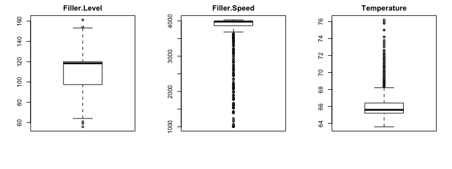

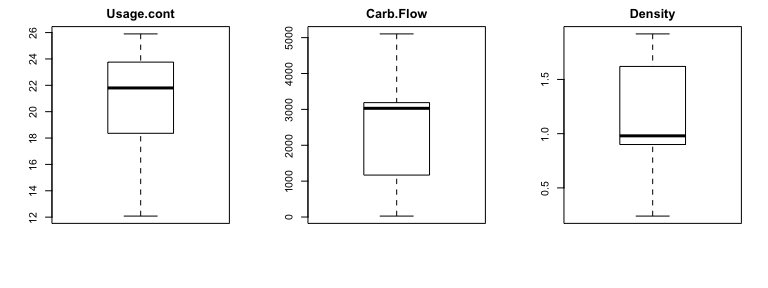

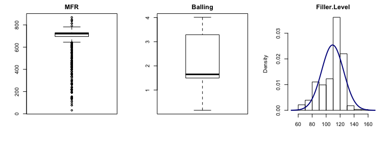

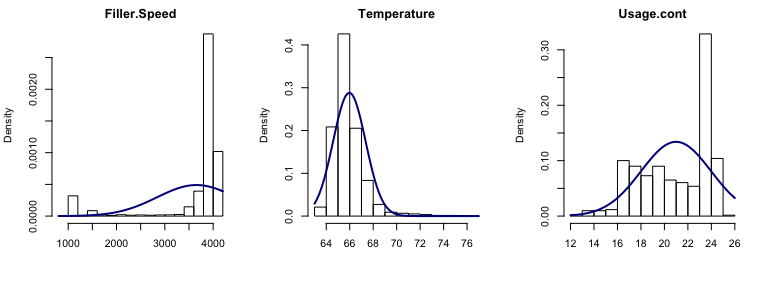

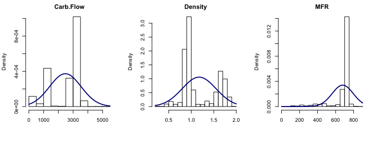

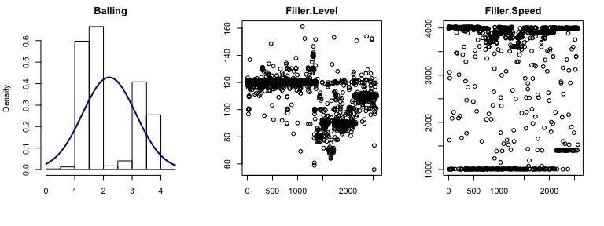

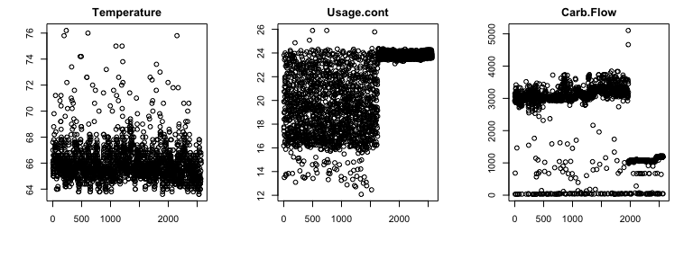

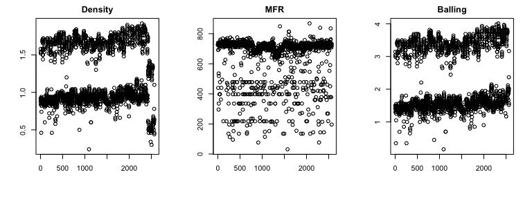

Based on a quick analysis of the basic statistics and plots, all of the predictor variables except Filler.Level will require a transformation to address issues with the variable’s data distribution.

The Filler.Level variable distribution is fairly normal with few outliers so we will not perform any transformations and, instead, perform an analysis of how the variable interacts with the response variable in various regression models.

```r
# Run algorithms using 10-fold cross-validation
trainControl <- trainControl(method="repeatedcv", number=10, repeats=3)
metric <- "RMSE"
# LM
set.seed(624)
fit.lm <- train(PH~Filler.Level, data=jeffsVars.imp, method="lm", metric=metric,
                preProc=c("center", "scale"), trControl=trainControl)
# GLM
set.seed(624)
fit.glm <- train(PH~Filler.Level, data=jeffsVars.imp, method="glm", metric=metric,
                 preProc=c("center", "scale"), trControl=trainControl)
# GLMNET
set.seed(624)
#fit.glmnet <- train(PH~Filler.Speed, data=jeffsVars.imp, method="glmnet", metric=metric,
#                    preProc=c("center", "scale"), trControl=trainControl)
# SVM
set.seed(624)
fit.svm <- train(PH~Filler.Level, data=jeffsVars.imp, method="svmRadial", metric=metric,
                 preProc=c("center", "scale"), trControl=trainControl)
# CART
set.seed(624)
grid <- expand.grid(.cp=c(0, 0.05, 0.1))
fit.cart <- train(PH~Filler.Level, data=jeffsVars.imp, method="rpart", metric=metric,
                  tuneGrid=grid, preProc=c("center", "scale"),
                  trControl=trainControl)
# KNN
set.seed(624)
fit.knn <- train(PH~Filler.Level, data=jeffsVars.imp, method="knn", metric=metric,
                 preProc=c("center", "scale"), trControl=trainControl)
# Compare algorithms
#feature_results <- resamples(list(LM=fit.lm, GLM=fit.glm, GLMNET=fit.glmnet,
#                                  SVM=fit.svm, CART=fit.cart, KNN=fit.knn))
feature_results <- resamples(list(LM=fit.lm, GLM=fit.glm,
                                  SVM=fit.svm, CART=fit.cart, KNN=fit.knn))
summary(feature_results)
```

```
Call:
summary.resamples(object = feature_results)

Models: LM, GLM, SVM, CART, KNN
Number of resamples: 30

MAE
          Min.   1st Qu.    Median      Mean   3rd Qu.      Max. NA's
LM   0.1199261 0.1281244 0.1313950 0.1311100 0.1339878 0.1392147    0
GLM  0.1199261 0.1281244 0.1313950 0.1311100 0.1339878 0.1392147    0
SVM  0.1131258 0.1218688 0.1237426 0.1239324 0.1253183 0.1344269    0
CART 0.1136366 0.1238764 0.1258057 0.1262717 0.1289814 0.1330906    0
KNN  0.1164612 0.1249888 0.1263389 0.1272193 0.1297673 0.1368292    0

RMSE
          Min.   1st Qu.    Median      Mean   3rd Qu.      Max. NA's
LM   0.1451885 0.1593468 0.1627832 0.1631358 0.1672270 0.1763973    0
GLM  0.1451885 0.1593468 0.1627832 0.1631358 0.1672270 0.1763973    0
SVM  0.1424080 0.1543040 0.1573187 0.1582779 0.1611313 0.1745063    0
CART 0.1399031 0.1549376 0.1591167 0.1587364 0.1618212 0.1730624    0
KNN  0.1449128 0.1568209 0.1596527 0.1603395 0.1636155 0.1773467    0

Rsquared
           Min.    1st Qu.    Median      Mean   3rd Qu.      Max. NA's
LM   0.02991084 0.08800982 0.1074782 0.1087563 0.1245566 0.1881467    0
GLM  0.02991084 0.08800982 0.1074782 0.1087563 0.1245566 0.1881467    0
SVM  0.06336435 0.15450614 0.1727260 0.1699975 0.1937771 0.2264947    0
CART 0.06792278 0.13725957 0.1605747 0.1552855 0.1815269 0.2076281    0
KNN  0.06642887 0.13098175 0.1470696 0.1425218 0.1594082 0.1864391    0
```

Next, we’ll explore the effect of Box Cox transformations on the predictor variables with skewed or non-normal distributions.

We’ll start with Filler.Speed first.

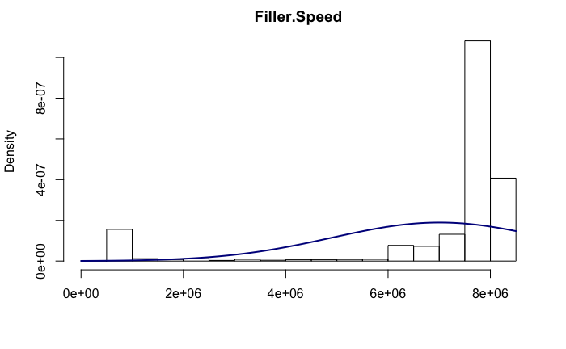

```r
# perform the Box Cox transformation and then look at the distribution
lambda <- BoxCox.lambda(jeffsVars.pred$Filler.Speed)
trans <- BoxCox(jeffsVars.pred$Filler.Speed,lambda)
  m <- mean(trans)
  s <- sd(trans)
  hist(trans,freq=FALSE,main = "Filler.Speed",xlab="")
  curve(dnorm(x,mean=m,sd=s),col="darkblue",lwd=2,add=TRUE)
```

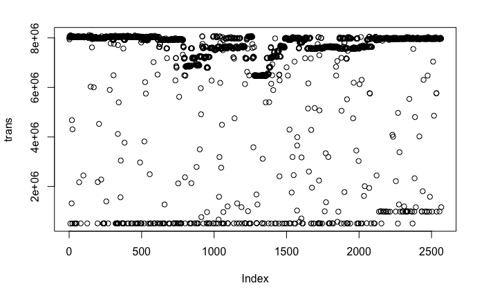

```r
  plot(trans)
```

```r
jeffsVars.imp <- cbind(jeffsVars.imp,Filler.Speed.Trans=trans)
```

```r
# Run algorithms using 10-fold cross-validation
trainControl <- trainControl(method="repeatedcv", number=10, repeats=3)
metric <- "RMSE"
# LM
set.seed(624)
fit.lm <- train(PH~Filler.Speed.Trans, data=jeffsVars.imp, method="lm", metric=metric,
                preProc=c("center", "scale"), trControl=trainControl)
# GLM
set.seed(624)
fit.glm <- train(PH~Filler.Speed.Trans, data=jeffsVars.imp, method="glm", metric=metric,
                 preProc=c("center", "scale"), trControl=trainControl)
# GLMNET
set.seed(624)
#fit.glmnet <- train(PH~Filler.Speed, data=jeffsVars.imp, method="glmnet", metric=metric,
#                    preProc=c("center", "scale"), trControl=trainControl)
# SVM
set.seed(624)
fit.svm <- train(PH~Filler.Speed.Trans, data=jeffsVars.imp, method="svmRadial", metric=metric,
                 preProc=c("center", "scale"), trControl=trainControl)
# CART
set.seed(624)
grid <- expand.grid(.cp=c(0, 0.05, 0.1))
fit.cart <- train(PH~Filler.Speed.Trans, data=jeffsVars.imp, method="rpart", metric=metric,
                  tuneGrid=grid, preProc=c("center", "scale"),
                  trControl=trainControl)
# KNN
set.seed(624)
fit.knn <- train(PH~Filler.Speed.Trans, data=jeffsVars.imp, method="knn", metric=metric,
                 preProc=c("center", "scale"), trControl=trainControl)
# Compare algorithms
#feature_results <- resamples(list(LM=fit.lm, GLM=fit.glm, GLMNET=fit.glmnet,
#                                  SVM=fit.svm, CART=fit.cart, KNN=fit.knn))
feature_results <- resamples(list(LM=fit.lm, GLM=fit.glm,
                                  SVM=fit.svm, CART=fit.cart, KNN=fit.knn))
summary(feature_results)
```

```
Call:
summary.resamples(object = feature_results)

Models: LM, GLM, SVM, CART, KNN
Number of resamples: 30

MAE
          Min.   1st Qu.    Median      Mean   3rd Qu.      Max. NA's
LM   0.1271271 0.1374365 0.1386559 0.1388416 0.1417644 0.1451257    0
GLM  0.1271271 0.1374365 0.1386559 0.1388416 0.1417644 0.1451257    0
SVM  0.1265772 0.1362591 0.1385079 0.1381662 0.1414127 0.1456280    0
CART 0.1157576 0.1268439 0.1311770 0.1297055 0.1332474 0.1378634    0
KNN  0.1155639 0.1271801 0.1300643 0.1291071 0.1317473 0.1385513    0

RMSE
          Min.   1st Qu.    Median      Mean   3rd Qu.      Max. NA's
LM   0.1546334 0.1696752 0.1714918 0.1724403 0.1775011 0.1841049    0
GLM  0.1546334 0.1696752 0.1714918 0.1724403 0.1775011 0.1841049    0
SVM  0.1541268 0.1693772 0.1714379 0.1722320 0.1771875 0.1847449    0
CART 0.1455813 0.1623459 0.1660104 0.1654333 0.1691296 0.1811299    0
KNN  0.1465165 0.1609475 0.1647461 0.1643881 0.1678953 0.1799160    0

Rsquared
             Min.      1st Qu.      Median        Mean     3rd Qu.       Max. NA's
LM   2.137087e-05 0.0008358875 0.002481740 0.004529717 0.007498573 0.01993620    0
GLM  2.137087e-05 0.0008358875 0.002481740 0.004529717 0.007498573 0.01993620    0
SVM  6.547884e-09 0.0020506709 0.005169062 0.007219714 0.011290672 0.02258667    0
CART 5.021938e-02 0.0695262301 0.087438747 0.092755331 0.108347819 0.17566135    0
KNN  5.646683e-02 0.0734006515 0.098356130 0.099944424 0.117822908 0.19538893    0
```

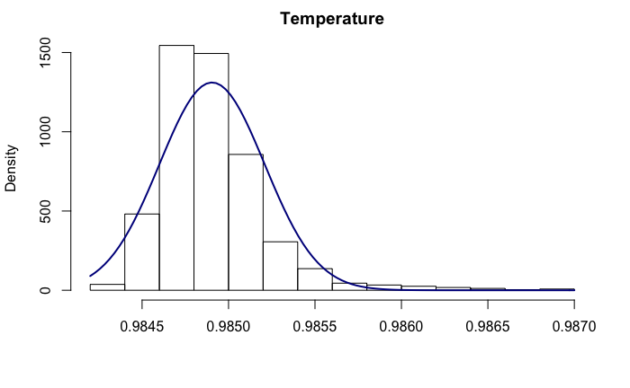

```r
# look at a couple of the variables first
lambda <- BoxCox.lambda(jeffsVars.pred$Temperature)
trans <- BoxCox(jeffsVars.pred$Temperature,lambda)
  m <- mean(trans)
  s <- sd(trans)
  hist(trans,freq=FALSE,main = "Temperature",xlab="")
  curve(dnorm(x,mean=m,sd=s),col="darkblue",lwd=2,add=TRUE)
```

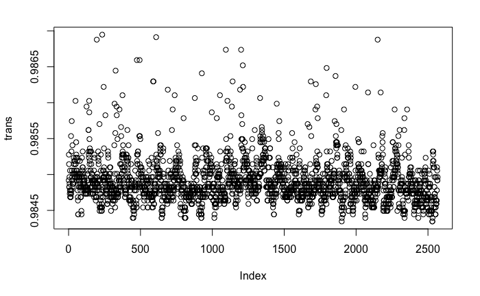

```r
  plot(trans)
```

```r
jeffsVars.imp <- cbind(jeffsVars.imp,Temperature.Trans=trans)
```

```r
# Run algorithms using 10-fold cross-validation
trainControl <- trainControl(method="repeatedcv", number=10, repeats=3)
metric <- "RMSE"
# LM
set.seed(624)
fit.lm <- train(PH~Temperature.Trans, data=jeffsVars.imp, method="lm", metric=metric,
                preProc=c("center", "scale"), trControl=trainControl)
# GLM
set.seed(624)
fit.glm <- train(PH~Temperature.Trans, data=jeffsVars.imp, method="glm", metric=metric,
                 preProc=c("center", "scale"), trControl=trainControl)
# GLMNET
set.seed(624)
#fit.glmnet <- train(PH~Filler.Speed, data=jeffsVars.imp, method="glmnet", metric=metric,
#                    preProc=c("center", "scale"), trControl=trainControl)
# SVM
set.seed(624)
fit.svm <- train(PH~Temperature.Trans, data=jeffsVars.imp, method="svmRadial", metric=metric,
                 preProc=c("center", "scale"), trControl=trainControl)
# CART
set.seed(624)
grid <- expand.grid(.cp=c(0, 0.05, 0.1))
fit.cart <- train(PH~Temperature.Trans, data=jeffsVars.imp, method="rpart", metric=metric,
                  tuneGrid=grid, preProc=c("center", "scale"),
                  trControl=trainControl)
# KNN
set.seed(624)
fit.knn <- train(PH~Temperature.Trans, data=jeffsVars.imp, method="knn", metric=metric,
                 preProc=c("center", "scale"), trControl=trainControl)
# Compare algorithms
#feature_results <- resamples(list(LM=fit.lm, GLM=fit.glm, GLMNET=fit.glmnet,
#                                  SVM=fit.svm, CART=fit.cart, KNN=fit.knn))
feature_results <- resamples(list(LM=fit.lm, GLM=fit.glm,
                                  SVM=fit.svm, CART=fit.cart, KNN=fit.knn))
summary(feature_results)
```

```
Call:
summary.resamples(object = feature_results)

Models: LM, GLM, SVM, CART, KNN
Number of resamples: 30

MAE
          Min.   1st Qu.    Median      Mean   3rd Qu.      Max. NA's
LM   0.1278105 0.1340956 0.1369150 0.1370235 0.1402655 0.1426813    0
GLM  0.1278105 0.1340956 0.1369150 0.1370235 0.1402655 0.1426813    0
SVM  0.1265387 0.1317022 0.1368865 0.1354859 0.1393432 0.1415505    0
CART 0.1268328 0.1317439 0.1363368 0.1358339 0.1394294 0.1448834    0
KNN  0.1256050 0.1315098 0.1361863 0.1354296 0.1394472 0.1432579    0

RMSE
          Min.   1st Qu.    Median      Mean   3rd Qu.      Max. NA's
LM   0.1553825 0.1671373 0.1700994 0.1702343 0.1754736 0.1825119    0
GLM  0.1553825 0.1671373 0.1700994 0.1702343 0.1754736 0.1825119    0
SVM  0.1552182 0.1656632 0.1676491 0.1686712 0.1737410 0.1811136    0
CART 0.1551501 0.1653605 0.1687975 0.1691964 0.1736030 0.1820012    0
KNN  0.1531236 0.1653033 0.1682061 0.1687562 0.1734587 0.1812025    0

Rsquared
             Min.    1st Qu.     Median       Mean    3rd Qu.       Max. NA's
LM   0.0001357553 0.01368939 0.02800352 0.02993911 0.04019668 0.08577128    0
GLM  0.0001357553 0.01368939 0.02800352 0.02993911 0.04019668 0.08577128    0
SVM  0.0066201640 0.02298070 0.04643837 0.04965609 0.07758298 0.10173359    0
CART 0.0045138006 0.01946966 0.04146873 0.04661745 0.06034815 0.12873034    0
KNN  0.0037619594 0.02154911 0.04466638 0.05052044 0.06518435 0.13505232    0
```

Next, we’ll work with the Usage.cont variable.

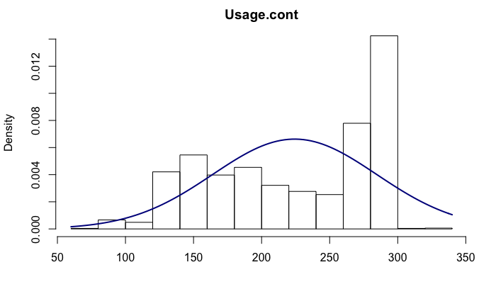

```r
# look at a couple of the variables first
lambda <- BoxCox.lambda(jeffsVars.pred$Usage.cont)
trans <- BoxCox(jeffsVars.pred$Usage.cont,lambda)
  m <- mean(trans)
  s <- sd(trans)
  hist(trans,freq=FALSE,main = "Usage.cont",xlab="")
  curve(dnorm(x,mean=m,sd=s),col="darkblue",lwd=2,add=TRUE)
```

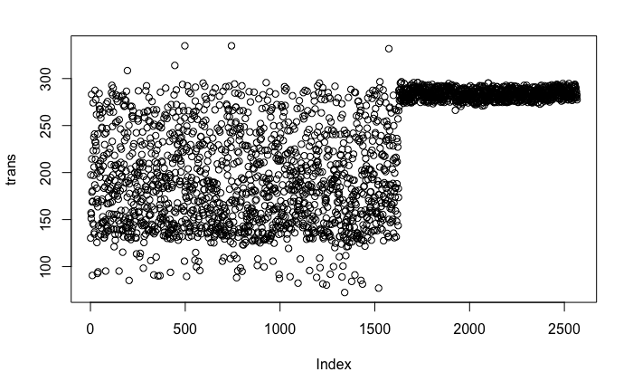

```r
  plot(trans)
```

```r
jeffsVars.imp <- cbind(jeffsVars.imp,Usage.cont.Trans=trans)
```

```r
# Run algorithms using 10-fold cross-validation
trainControl <- trainControl(method="repeatedcv", number=10, repeats=3)
metric <- "RMSE"
# LM
set.seed(624)
fit.lm <- train(PH~Usage.cont.Trans, data=jeffsVars.imp, method="lm", metric=metric,
                preProc=c("center", "scale"), trControl=trainControl)
# GLM
set.seed(624)
fit.glm <- train(PH~Usage.cont.Trans, data=jeffsVars.imp, method="glm", metric=metric,
                 preProc=c("center", "scale"), trControl=trainControl)
# GLMNET
set.seed(624)
#fit.glmnet <- train(PH~Filler.Speed, data=jeffsVars.imp, method="glmnet", metric=metric,
#                    preProc=c("center", "scale"), trControl=trainControl)
# SVM
set.seed(624)
fit.svm <- train(PH~Usage.cont.Trans, data=jeffsVars.imp, method="svmRadial", metric=metric,
                 preProc=c("center", "scale"), trControl=trainControl)
# CART
set.seed(624)
grid <- expand.grid(.cp=c(0, 0.05, 0.1))
fit.cart <- train(PH~Usage.cont.Trans, data=jeffsVars.imp, method="rpart", metric=metric,
                  tuneGrid=grid, preProc=c("center", "scale"),
                  trControl=trainControl)
# KNN
set.seed(624)
fit.knn <- train(PH~Usage.cont.Trans, data=jeffsVars.imp, method="knn", metric=metric,
                 preProc=c("center", "scale"), trControl=trainControl)
# Compare algorithms
#feature_results <- resamples(list(LM=fit.lm, GLM=fit.glm, GLMNET=fit.glmnet,
#                                  SVM=fit.svm, CART=fit.cart, KNN=fit.knn))
feature_results <- resamples(list(LM=fit.lm, GLM=fit.glm,
                                  SVM=fit.svm, CART=fit.cart, KNN=fit.knn))
summary(feature_results)
```

```
Call:
summary.resamples(object = feature_results)

Models: LM, GLM, SVM, CART, KNN
Number of resamples: 30

MAE
          Min.   1st Qu.    Median      Mean   3rd Qu.      Max. NA's
LM   0.1212309 0.1263587 0.1298105 0.1296643 0.1326824 0.1369718    0
GLM  0.1212309 0.1263587 0.1298105 0.1296643 0.1326824 0.1369718    0
SVM  0.1183266 0.1221644 0.1249251 0.1254442 0.1275796 0.1368180    0
CART 0.1165458 0.1217656 0.1247073 0.1252280 0.1278800 0.1356790    0
KNN  0.1190144 0.1250928 0.1273662 0.1287580 0.1308184 0.1443548    0

RMSE
          Min.   1st Qu.    Median      Mean   3rd Qu.      Max. NA's
LM   0.1473717 0.1583877 0.1637792 0.1629019 0.1667102 0.1774041    0
GLM  0.1473717 0.1583877 0.1637792 0.1629019 0.1667102 0.1774041    0
SVM  0.1442965 0.1547026 0.1582113 0.1585357 0.1614158 0.1745282    0
CART 0.1419821 0.1532376 0.1579970 0.1574822 0.1606966 0.1736145    0
KNN  0.1465935 0.1596660 0.1621772 0.1621363 0.1636656 0.1806212    0

Rsquared
           Min.    1st Qu.    Median      Mean   3rd Qu.      Max. NA's
LM   0.05245486 0.08748922 0.1124225 0.1113521 0.1313542 0.2093910    0
GLM  0.05245486 0.08748922 0.1124225 0.1113521 0.1313542 0.2093910    0
SVM  0.06324386 0.14614032 0.1609252 0.1624972 0.1989244 0.2267417    0
CART 0.09043158 0.14867365 0.1722759 0.1693350 0.2073159 0.2353797    0
KNN  0.05864567 0.11051545 0.1392281 0.1365235 0.1636888 0.1997443    0
```

Next, we’ll work with the Carb.Flow variable.

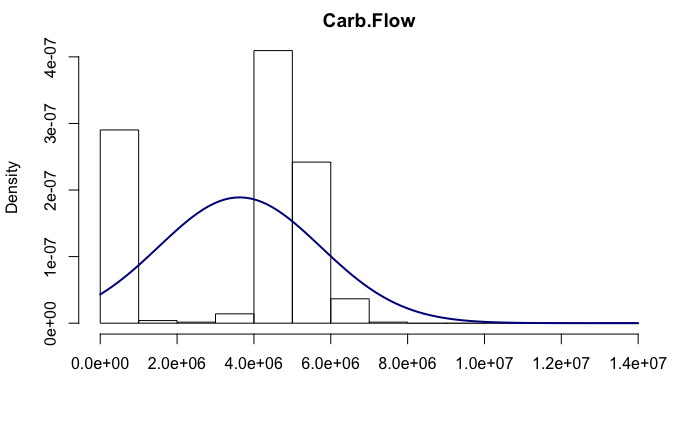

```r
# look at a couple of the variables first
lambda <- BoxCox.lambda(jeffsVars.pred$Carb.Flow)
trans <- BoxCox(jeffsVars.pred$Carb.Flow,lambda)
  m <- mean(trans)
  s <- sd(trans)
  hist(trans,freq=FALSE,main = "Carb.Flow",xlab="")
  curve(dnorm(x,mean=m,sd=s),col="darkblue",lwd=2,add=TRUE)
```

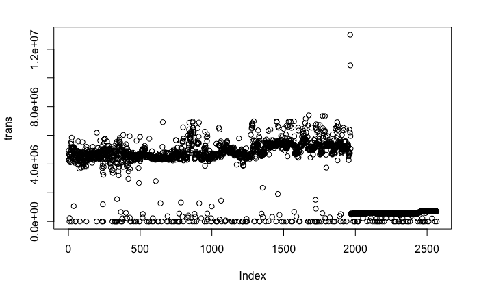

```r
  plot(trans)
```

```r
jeffsVars.imp <- cbind(jeffsVars.imp,Carb.Flow.Trans=trans)
```

```r
# Run algorithms using 10-fold cross-validation
trainControl <- trainControl(method="repeatedcv", number=10, repeats=3)
metric <- "RMSE"
# LM
set.seed(624)
fit.lm <- train(PH~Carb.Flow.Trans, data=jeffsVars.imp, method="lm", metric=metric,
                preProc=c("center", "scale"), trControl=trainControl)
# GLM
set.seed(624)
fit.glm <- train(PH~Carb.Flow.Trans, data=jeffsVars.imp, method="glm", metric=metric,
                 preProc=c("center", "scale"), trControl=trainControl)
# GLMNET
set.seed(624)
#fit.glmnet <- train(PH~Filler.Speed, data=jeffsVars.imp, method="glmnet", metric=metric,
#                    preProc=c("center", "scale"), trControl=trainControl)
# SVM
set.seed(624)
fit.svm <- train(PH~Carb.Flow.Trans, data=jeffsVars.imp, method="svmRadial", metric=metric,
                 preProc=c("center", "scale"), trControl=trainControl)
# CART
set.seed(624)
grid <- expand.grid(.cp=c(0, 0.05, 0.1))
fit.cart <- train(PH~Carb.Flow.Trans, data=jeffsVars.imp, method="rpart", metric=metric,
                  tuneGrid=grid, preProc=c("center", "scale"),
                  trControl=trainControl)
# KNN
set.seed(624)
fit.knn <- train(PH~Carb.Flow.Trans, data=jeffsVars.imp, method="knn", metric=metric,
                 preProc=c("center", "scale"), trControl=trainControl)
# Compare algorithms
#feature_results <- resamples(list(LM=fit.lm, GLM=fit.glm, GLMNET=fit.glmnet,
#                                  SVM=fit.svm, CART=fit.cart, KNN=fit.knn))
feature_results <- resamples(list(LM=fit.lm, GLM=fit.glm,
                                  SVM=fit.svm, CART=fit.cart, KNN=fit.knn))
summary(feature_results)
```

```
Call:
summary.resamples(object = feature_results)

Models: LM, GLM, SVM, CART, KNN
Number of resamples: 30

MAE
          Min.   1st Qu.    Median      Mean   3rd Qu.      Max. NA's
LM   0.1241590 0.1350019 0.1372156 0.1370566 0.1399197 0.1450984    0
GLM  0.1241590 0.1350019 0.1372156 0.1370566 0.1399197 0.1450984    0
SVM  0.1182386 0.1285833 0.1314945 0.1314060 0.1352430 0.1395397    0
CART 0.1197995 0.1333895 0.1369842 0.1369749 0.1407286 0.1490684    0
KNN  0.1181917 0.1318372 0.1344650 0.1347489 0.1380536 0.1467401    0

RMSE
          Min.   1st Qu.    Median      Mean   3rd Qu.      Max. NA's
LM   0.1512929 0.1679175 0.1708079 0.1704290 0.1736359 0.1845543    0
GLM  0.1512929 0.1679175 0.1708079 0.1704290 0.1736359 0.1845543    0
SVM  0.1458272 0.1617833 0.1656619 0.1655123 0.1693437 0.1819306    0
CART 0.1479910 0.1678234 0.1716424 0.1715162 0.1747871 0.1903829    0
KNN  0.1455781 0.1641101 0.1678550 0.1681360 0.1718805 0.1868015    0

Rsquared
             Min.    1st Qu.     Median       Mean    3rd Qu.       Max. NA's
LM   1.059423e-07 0.01393981 0.02860950 0.02810766 0.03960265 0.06651414    0
GLM  1.059423e-07 0.01393981 0.02860950 0.02810766 0.03960265 0.06651414    0
SVM  4.196492e-02 0.05949033 0.08950717 0.08553244 0.10348188 0.15548168    0
CART 1.396038e-02 0.04298899 0.05784027 0.06676838 0.09762269 0.13037908    0
KNN  3.484078e-02 0.05143531 0.07508769 0.07907596 0.10287869 0.14052893    0
```

Next, we’ll work with the Density variable.

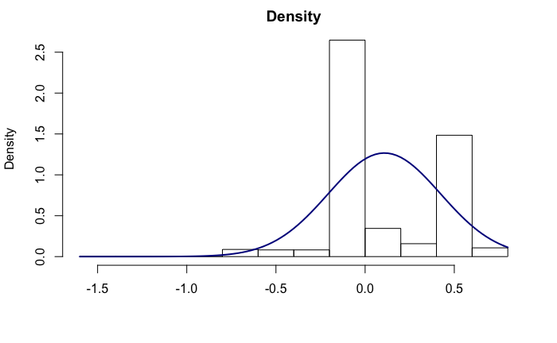

```r
# look at a couple of the variables first
lambda <- BoxCox.lambda(jeffsVars.pred$Density)
trans <- BoxCox(jeffsVars.pred$Density,lambda)
  m <- mean(trans)
  s <- sd(trans)
  hist(trans,freq=FALSE,main = "Density",xlab="")
  curve(dnorm(x,mean=m,sd=s),col="darkblue",lwd=2,add=TRUE)
```

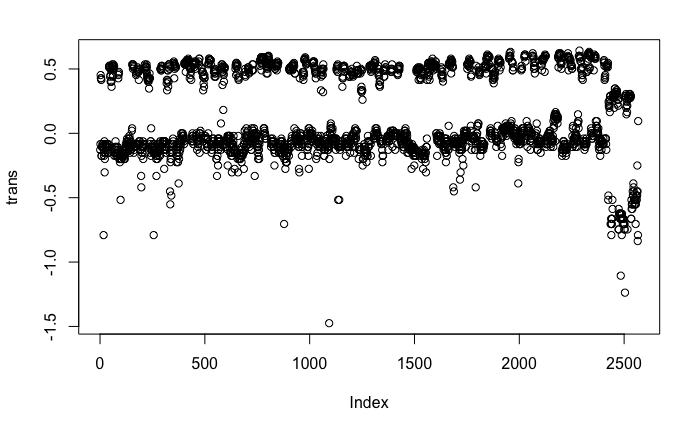

```r
  plot(trans)
```

```r
jeffsVars.imp <- cbind(jeffsVars.imp,Density.Trans=trans)
```

```r
# Run algorithms using 10-fold cross-validation
trainControl <- trainControl(method="repeatedcv", number=10, repeats=3)
metric <- "RMSE"
# LM
set.seed(624)
fit.lm <- train(PH~Density.Trans, data=jeffsVars.imp, method="lm", metric=metric,
                preProc=c("center", "scale"), trControl=trainControl)
# GLM
set.seed(624)
fit.glm <- train(PH~Density.Trans, data=jeffsVars.imp, method="glm", metric=metric,
                 preProc=c("center", "scale"), trControl=trainControl)
# GLMNET
set.seed(624)
#fit.glmnet <- train(PH~Filler.Speed, data=jeffsVars.imp, method="glmnet", metric=metric,
#                    preProc=c("center", "scale"), trControl=trainControl)
# SVM
set.seed(624)
fit.svm <- train(PH~Density.Trans, data=jeffsVars.imp, method="svmRadial", metric=metric,
                 preProc=c("center", "scale"), trControl=trainControl)
# CART
set.seed(624)
grid <- expand.grid(.cp=c(0, 0.05, 0.1))
fit.cart <- train(PH~Density.Trans, data=jeffsVars.imp, method="rpart", metric=metric,
                  tuneGrid=grid, preProc=c("center", "scale"),
                  trControl=trainControl)
# KNN
set.seed(624)
fit.knn <- train(PH~Density.Trans, data=jeffsVars.imp, method="knn", metric=metric,
                 preProc=c("center", "scale"), trControl=trainControl)
# Compare algorithms
#feature_results <- resamples(list(LM=fit.lm, GLM=fit.glm, GLMNET=fit.glmnet,
#                                  SVM=fit.svm, CART=fit.cart, KNN=fit.knn))
feature_results <- resamples(list(LM=fit.lm, GLM=fit.glm,
                                  SVM=fit.svm, CART=fit.cart, KNN=fit.knn))
summary(feature_results)
```

```
Call:
summary.resamples(object = feature_results)

Models: LM, GLM, SVM, CART, KNN
Number of resamples: 30

MAE
          Min.   1st Qu.    Median      Mean   3rd Qu.      Max. NA's
LM   0.1259148 0.1366626 0.1375890 0.1381896 0.1410775 0.1441072    0
GLM  0.1259148 0.1366626 0.1375890 0.1381896 0.1410775 0.1441072    0
SVM  0.1206728 0.1294410 0.1328013 0.1324740 0.1355260 0.1388555    0
CART 0.1222047 0.1296428 0.1328848 0.1323287 0.1351617 0.1376902    0
KNN  0.1221373 0.1296131 0.1325631 0.1321520 0.1350807 0.1382186    0

RMSE
          Min.   1st Qu.    Median      Mean   3rd Qu.      Max. NA's
LM   0.1543272 0.1691211 0.1718563 0.1720389 0.1768771 0.1830566    0
GLM  0.1543272 0.1691211 0.1718563 0.1720389 0.1768771 0.1830566    0
SVM  0.1512251 0.1637221 0.1664892 0.1671117 0.1719010 0.1783252    0
CART 0.1515065 0.1622659 0.1675605 0.1669726 0.1717553 0.1759668    0
KNN  0.1508530 0.1625653 0.1671192 0.1666046 0.1715170 0.1757176    0

Rsquared
             Min.     1st Qu.      Median        Mean    3rd Qu.       Max. NA's
LM   5.830486e-06 0.001985787 0.008314255 0.008010528 0.01125320 0.02306657    0
GLM  5.830486e-06 0.001985787 0.008314255 0.008010528 0.01125320 0.02306657    0
SVM  2.275359e-02 0.049529010 0.059899344 0.065049448 0.07770287 0.16028619    0
CART 1.912344e-02 0.052927012 0.066619049 0.070330750 0.08712817 0.13153455    0
KNN  2.675947e-02 0.058805891 0.068280337 0.072360521 0.08987026 0.13321256    0
```

Next, we’ll work with the MFR variable.

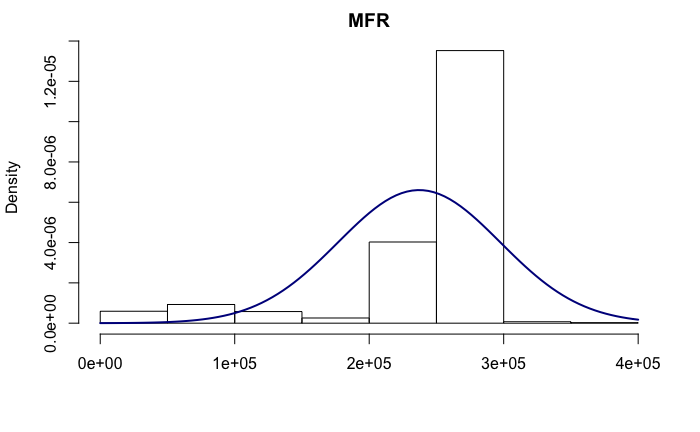

```r
# look at a couple of the variables first
lambda <- BoxCox.lambda(jeffsVars.pred$MFR)
trans <- BoxCox(jeffsVars.pred$MFR,lambda)
  m <- mean(trans)
  s <- sd(trans)
  hist(trans,freq=FALSE,main = "MFR",xlab="")
  curve(dnorm(x,mean=m,sd=s),col="darkblue",lwd=2,add=TRUE)
```

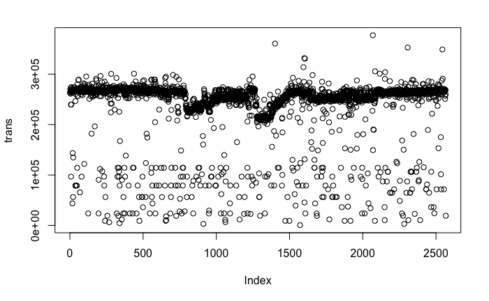

```r
  plot(trans)
```

```r
jeffsVars.imp <- cbind(jeffsVars.imp,MFR.Trans=trans)
```

```r
# Run algorithms using 10-fold cross-validation
trainControl <- trainControl(method="repeatedcv", number=10, repeats=3)
metric <- "RMSE"
# LM
set.seed(624)
fit.lm <- train(PH~MFR.Trans, data=jeffsVars.imp, method="lm", metric=metric,
                preProc=c("center", "scale"), trControl=trainControl)
# GLM
set.seed(624)
fit.glm <- train(PH~MFR.Trans, data=jeffsVars.imp, method="glm", metric=metric,
                 preProc=c("center", "scale"), trControl=trainControl)
# GLMNET
set.seed(624)
#fit.glmnet <- train(PH~Filler.Speed, data=jeffsVars.imp, method="glmnet", metric=metric,
#                    preProc=c("center", "scale"), trControl=trainControl)
# SVM
set.seed(624)
fit.svm <- train(PH~MFR.Trans, data=jeffsVars.imp, method="svmRadial", metric=metric,
                 preProc=c("center", "scale"), trControl=trainControl)
# CART
set.seed(624)
grid <- expand.grid(.cp=c(0, 0.05, 0.1))
fit.cart <- train(PH~MFR.Trans, data=jeffsVars.imp, method="rpart", metric=metric,
                  tuneGrid=grid, preProc=c("center", "scale"),
                  trControl=trainControl)
# KNN
set.seed(624)
fit.knn <- train(PH~MFR.Trans, data=jeffsVars.imp, method="knn", metric=metric,
                 preProc=c("center", "scale"), trControl=trainControl)
# Compare algorithms
#feature_results <- resamples(list(LM=fit.lm, GLM=fit.glm, GLMNET=fit.glmnet,
#                                  SVM=fit.svm, CART=fit.cart, KNN=fit.knn))
feature_results <- resamples(list(LM=fit.lm, GLM=fit.glm,
                                  SVM=fit.svm, CART=fit.cart, KNN=fit.knn))
summary(feature_results)
```

```
Call:
summary.resamples(object = feature_results)

Models: LM, GLM, SVM, CART, KNN
Number of resamples: 30

MAE
          Min.   1st Qu.    Median      Mean   3rd Qu.      Max. NA's
LM   0.1270756 0.1373516 0.1386403 0.1388247 0.1417125 0.1450320    0
GLM  0.1270756 0.1373516 0.1386403 0.1388247 0.1417125 0.1450320    0
SVM  0.1263771 0.1361596 0.1386324 0.1383113 0.1408449 0.1453993    0
CART 0.1272557 0.1372381 0.1387320 0.1387509 0.1417459 0.1451763    0
KNN  0.1254519 0.1357791 0.1411418 0.1399136 0.1436919 0.1496147    0

RMSE
          Min.   1st Qu.    Median      Mean   3rd Qu.      Max. NA's
LM   0.1545629 0.1695797 0.1714469 0.1724189 0.1774587 0.1840412    0
GLM  0.1545629 0.1695797 0.1714469 0.1724189 0.1774587 0.1840412    0
SVM  0.1538631 0.1697187 0.1719189 0.1722015 0.1769199 0.1839584    0
CART 0.1548066 0.1694532 0.1715767 0.1723899 0.1774563 0.1842563    0
KNN  0.1518083 0.1711542 0.1762776 0.1752267 0.1796651 0.1947678    0

Rsquared
             Min.      1st Qu.      Median        Mean     3rd Qu.       Max. NA's
LM   4.216384e-07 0.0008024287 0.001477218 0.004172054 0.005152598 0.01819657    0
GLM  4.216384e-07 0.0008024287 0.001477218 0.004172054 0.005152598 0.01819657    0
SVM  1.738417e-04 0.0012565835 0.003529501 0.007714849 0.010420306 0.03037429    0
CART           NA           NA          NA         NaN          NA         NA   30
KNN  1.442367e-06 0.0078903101 0.016524845 0.017671030 0.023888981 0.05511438    0
```

Next, we’ll work with the Bslling variable.

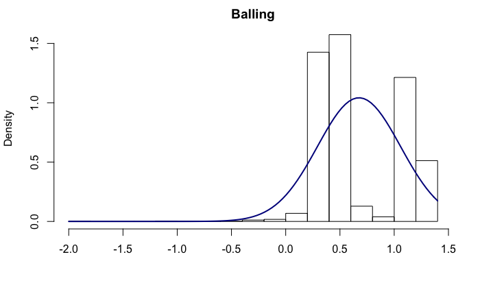

```r
# look at a couple of the variables first
lambda <- BoxCox.lambda(jeffsVars.pred$Balling)
trans <- BoxCox(jeffsVars.pred$Balling,lambda)
  m <- mean(trans)
  s <- sd(trans)
  hist(trans,freq=FALSE,main = "Balling",xlab="")
  curve(dnorm(x,mean=m,sd=s),col="darkblue",lwd=2,add=TRUE)
```

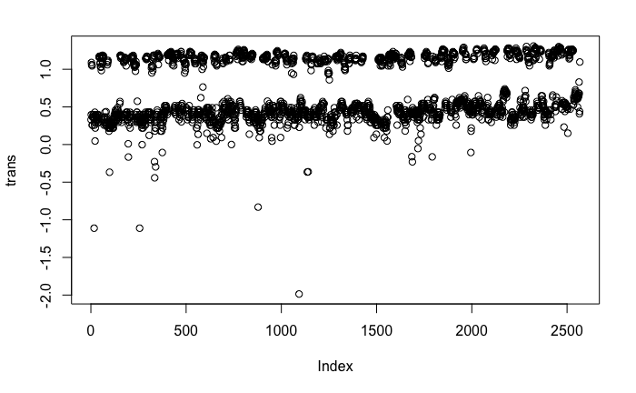

```r
  plot(trans)
```

```r
jeffsVars.imp <- cbind(jeffsVars.imp,Balling.Trans=trans)
```

```r
# Run algorithms using 10-fold cross-validation
trainControl <- trainControl(method="repeatedcv", number=10, repeats=3)
metric <- "RMSE"
# LM
set.seed(624)
fit.lm <- train(PH~Balling.Trans, data=jeffsVars.imp, method="lm", metric=metric,
                preProc=c("center", "scale"), trControl=trainControl)
# GLM
set.seed(624)
fit.glm <- train(PH~Balling.Trans, data=jeffsVars.imp, method="glm", metric=metric,
                 preProc=c("center", "scale"), trControl=trainControl)
# GLMNET
set.seed(624)
#fit.glmnet <- train(PH~Filler.Speed, data=jeffsVars.imp, method="glmnet", metric=metric,
#                    preProc=c("center", "scale"), trControl=trainControl)
# SVM
set.seed(624)
fit.svm <- train(PH~Balling.Trans, data=jeffsVars.imp, method="svmRadial", metric=metric,
                 preProc=c("center", "scale"), trControl=trainControl)
# CART
set.seed(624)
grid <- expand.grid(.cp=c(0, 0.05, 0.1))
fit.cart <- train(PH~Balling.Trans, data=jeffsVars.imp, method="rpart", metric=metric,
                  tuneGrid=grid, preProc=c("center", "scale"),
                  trControl=trainControl)
# KNN
set.seed(624)
fit.knn <- train(PH~Balling.Trans, data=jeffsVars.imp, method="knn", metric=metric,
                 preProc=c("center", "scale"), trControl=trainControl)
# Compare algorithms
#feature_results <- resamples(list(LM=fit.lm, GLM=fit.glm, GLMNET=fit.glmnet,
#                                  SVM=fit.svm, CART=fit.cart, KNN=fit.knn))
feature_results <- resamples(list(LM=fit.lm, GLM=fit.glm,
                                  SVM=fit.svm, CART=fit.cart, KNN=fit.knn))
summary(feature_results)
```

```
Call:
summary.resamples(object = feature_results)

Models: LM, GLM, SVM, CART, KNN
Number of resamples: 30

MAE
          Min.   1st Qu.    Median      Mean   3rd Qu.      Max. NA's
LM   0.1266276 0.1369666 0.1382339 0.1385185 0.1415090 0.1447364    0
GLM  0.1266276 0.1369666 0.1382339 0.1385185 0.1415090 0.1447364    0
SVM  0.1210123 0.1306028 0.1331553 0.1323495 0.1350785 0.1387711    0
CART 0.1210872 0.1284054 0.1324030 0.1314425 0.1351302 0.1364562    0
KNN  0.1208905 0.1284944 0.1320758 0.1307691 0.1340340 0.1364024    0

RMSE
          Min.   1st Qu.    Median      Mean   3rd Qu.      Max. NA's
LM   0.1547101 0.1693703 0.1716753 0.1724054 0.1772578 0.1840733    0
GLM  0.1547101 0.1693703 0.1716753 0.1724054 0.1772578 0.1840733    0
SVM  0.1500447 0.1632652 0.1655961 0.1659218 0.1715056 0.1769712    0
CART 0.1492675 0.1621286 0.1660909 0.1660337 0.1721116 0.1774060    0
KNN  0.1495694 0.1621816 0.1646886 0.1651819 0.1709270 0.1756947    0

Rsquared
             Min.     1st Qu.      Median        Mean     3rd Qu.       Max. NA's
LM   6.241192e-06 0.000790578 0.002662098 0.004693808 0.006526726 0.02629823    0
GLM  6.241192e-06 0.000790578 0.002662098 0.004693808 0.006526726 0.02629823    0
SVM  3.136045e-02 0.060732038 0.069267516 0.077273276 0.090490935 0.15194152    0
CART 3.125766e-02 0.061486740 0.083684605 0.085903689 0.102055374 0.15520604    0
KNN  3.571639e-02 0.066262307 0.084046226 0.092334003 0.118251132 0.15846199    0
```

The 1-on-1 modeling results have been so poor that we’re going to try a modeling experiment using all variables in the set (in their transformed state if applicable).

```r
# generate a generalize linear model with all variables
whole.model <- glm(PH ~ Filler.Level+Filler.Speed.Trans+Temperature.Trans+Usage.cont.Trans+Carb.Flow.Trans+Density.Trans+MFR.Trans+Balling.Trans, family=gaussian(link='identity'),data=jeffsVars.imp)
stepwise <- step(whole.model, direction = "both")
```

```
Start:  AIC=-2344.1
PH ~ Filler.Level + Filler.Speed.Trans + Temperature.Trans +
    Usage.cont.Trans + Carb.Flow.Trans + Density.Trans + MFR.Trans +
    Balling.Trans

                     Df Deviance     AIC
- Filler.Speed.Trans  1   59.840 -2346.0
<none>                    59.839 -2344.1
- MFR.Trans           1   59.887 -2344.0
- Balling.Trans       1   59.949 -2341.4
- Density.Trans       1   60.018 -2338.4
- Carb.Flow.Trans     1   60.282 -2327.2
- Usage.cont.Trans    1   61.984 -2255.7
- Temperature.Trans   1   63.305 -2201.6
- Filler.Level        1   64.473 -2154.6

Step:  AIC=-2346.04
PH ~ Filler.Level + Temperature.Trans + Usage.cont.Trans + Carb.Flow.Trans +
    Density.Trans + MFR.Trans + Balling.Trans

                     Df Deviance     AIC
<none>                    59.840 -2346.0
+ Filler.Speed.Trans  1   59.839 -2344.1
- Balling.Trans       1   59.952 -2343.3
- Density.Trans       1   60.022 -2340.3
- Carb.Flow.Trans     1   60.306 -2328.1
- MFR.Trans           1   60.496 -2320.1
- Usage.cont.Trans    1   62.045 -2255.2
- Temperature.Trans   1   63.325 -2202.7
- Filler.Level        1   64.474 -2156.6
```

```r
stepwise
```

```
Call:  glm(formula = PH ~ Filler.Level + Temperature.Trans + Usage.cont.Trans +
    Carb.Flow.Trans + Density.Trans + MFR.Trans + Balling.Trans,
    family = gaussian(link = "identity"), data = jeffsVars.imp)

Coefficients:
      (Intercept)       Filler.Level  Temperature.Trans   Usage.cont.Trans
        1.399e+02          2.985e-03         -1.335e+02         -5.896e-04
  Carb.Flow.Trans      Density.Trans          MFR.Trans      Balling.Trans
        7.695e-09          7.213e-02         -2.980e-07         -4.732e-02

Degrees of Freedom: 2566 Total (i.e. Null);  2559 Residual
Null Deviance:      76.37
Residual Deviance: 59.84    AIC: -2346
```